# ARIMA_TIMESERIES_EU_COVID

# USING ADDITIVE MODEL

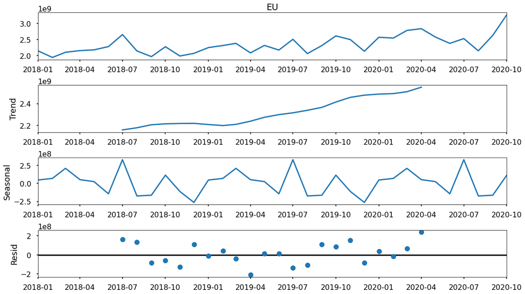

```python
import statsmodels.api as sm

decomposition = sm.tsa.seasonal_decompose(indexedDf.EU, model='additive')
plt.rcParams["figure.figsize"] = [16,9]
fig = decomposition.plot()
```

# USING MULTIPLICATIVE MODEL

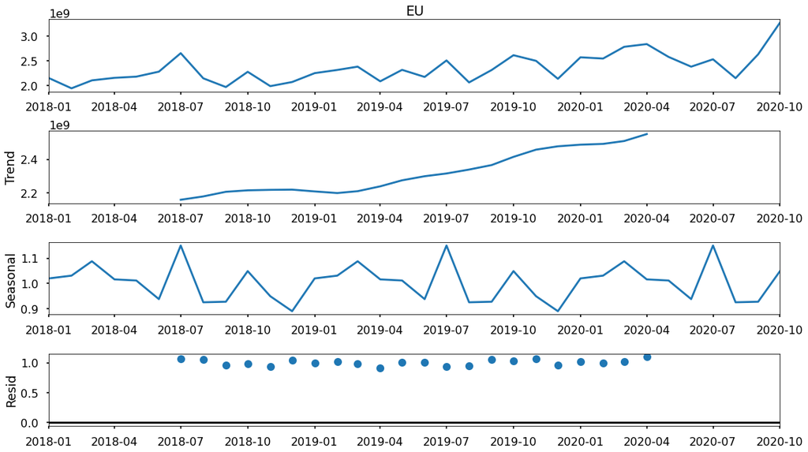

```python
import statsmodels.api as sm

decomposition2 = sm.tsa.seasonal_decompose(indexedDf.EU, model='multiplicative')
plt.rcParams["figure.figsize"] = [16,9]
fig = decomposition2.plot()
```

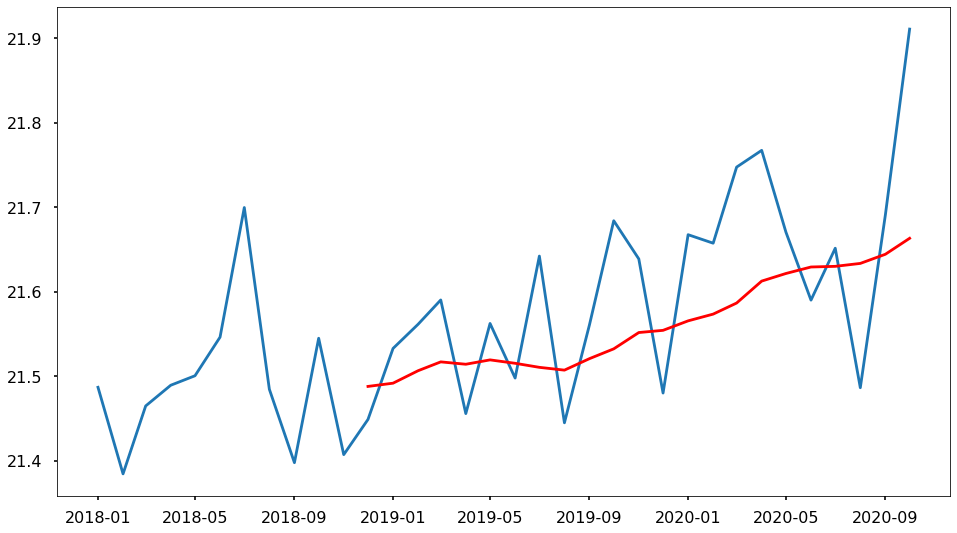

```python
#MOVING AVERAGE BY LOG
movingAverageLog = indexedDf_logScale.rolling(window=12).mean()
movingSTDLOg = indexedDf_logScale.rolling(window=12).std()
plt.plot(indexedDf_logScale)
plt.plot(movingAverageLog, color='red')
```

```python
#LET'S MAKE IT STASIONARY
#USING LOG
datasetLogScaleMinusMovingAverage = indexedDf_logScale - movingAverageLog
datasetLogScaleMinusMovingAverage.head(12)

#Remove NAN Values
datasetLogScaleMinusMovingAverage.dropna(inplace=True)
datasetLogScaleMinusMovingAverage.head(10)

#The data BELOW is the different
```

| period | EU |
| --- | --- |
| 2018-12-01 | -0.039033 |
| 2019-01-01 | 0.041107 |
| 2019-02-01 | 0.054970 |
| 2019-03-01 | 0.073249 |
| 2019-04-01 | -0.058381 |
| 2019-05-01 | 0.043078 |
| 2019-06-01 | -0.017450 |
| 2019-07-01 | 0.131622 |
| 2019-08-01 | -0.062303 |
| 2019-09-01 | 0.040126 |

```python
#USING LOG
from statsmodels.tsa.stattools import adfuller
def test_stationarity(timeseries):

    #Determining Rolling Statistics
    movingAverageLog = timeseries.rolling(window=12).mean()
    movingSTDLog = timeseries.rolling(window=12).std()

    #Plot Rolling Statistics
    orig = plt.plot(indexedDf,color='blue',label='Original') #originaldata
    mean = plt.plot(rolmean,color='red', label='Rolling Mean')
    std = plt.plot(rolstd, color='black',label='Rolling Std')
    plt.legend(loc='best')
    plt.title('Rolling Mean & Standar Deviation')
    plt.show(block=False)

    # Perform Dickey-Fuller test
    from statsmodels.tsa.stattools import adfuller
    print('Results of Dickey-Fuller Test :')
    dftest = adfuller(indexedDf['EU'], autolag='AIC') #AIC Akaike Info Criteria
    dfoutput = pd.Series(dftest[0:4], index=['Test statistics','p-value','#Lags Used','Number of Observation Used'])
    for key,value in dftest[4].items():
        dfoutput['Critical Value(%s)'%key] = value
    print(dfoutput)
```

```python
test_stationarity(datasetLogScaleMinusMovingAverage)
```

[output not shown]

```
Results of Dickey-Fuller Test :
Test statistics               -2.455649
p-value                        0.126642
#Lags Used                     0.000000
Number of Observation Used    33.000000
Critical Value(1%)            -3.646135
Critical Value(5%)            -2.954127
Critical Value(10%)           -2.615968
dtype: float64
```

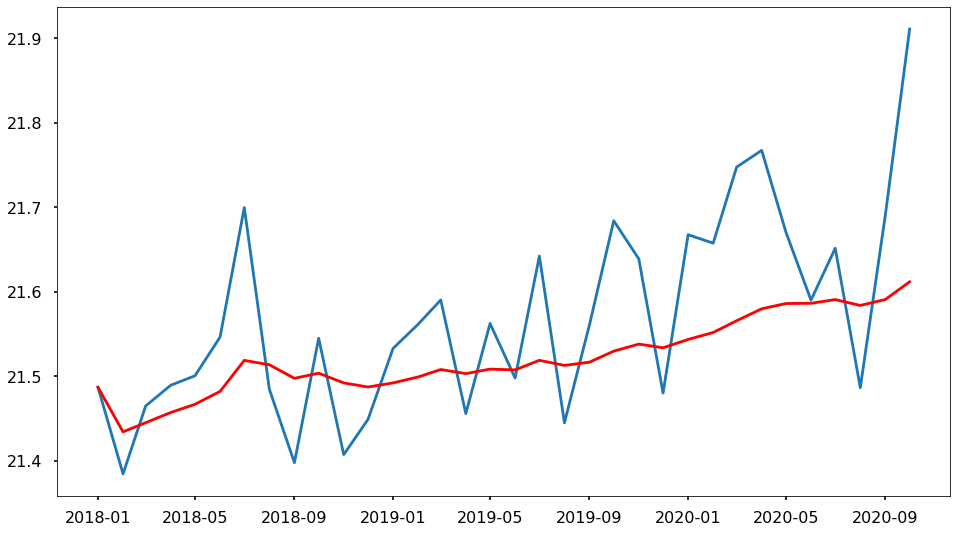

```python
#WEIGHT OF TIME SERIES
exponentialDecayWeightAverage = indexedDf_logScale.ewm(halflife=12,min_periods=0,adjust=True).mean()
plt.plot(indexedDf_logScale)
plt.plot(exponentialDecayWeightAverage, color='red')
```

```python
datasetLogScaleMinusExponencialDecayAverage = indexedDf_logScale - exponentialDecayWeightAverage
test_stationarity(datasetLogScaleMinusExponencialDecayAverage)
```

[output not shown]

```
Results of Dickey-Fuller Test :
Test statistics               -2.455649
p-value                        0.126642
#Lags Used                     0.000000
Number of Observation Used    33.000000
Critical Value(1%)            -3.646135
Critical Value(5%)            -2.954127
Critical Value(10%)           -2.615968
dtype: float64
```

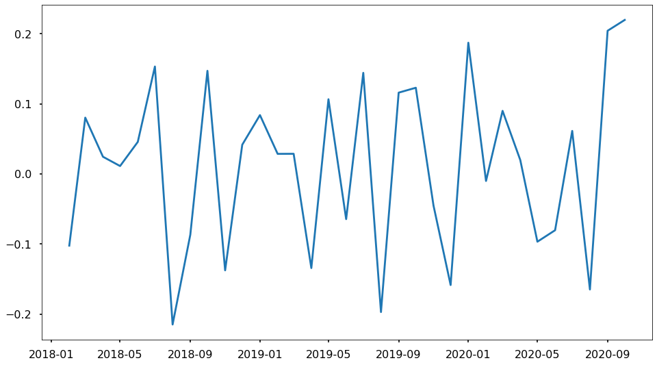

```python
#SHIFT ALL THOSE VALUE IF ALREADY STASIONARY
# FIND D
datasetLogDiffShifting = indexedDf_logScale - indexedDf_logScale.shift()
plt.plot(datasetLogDiffShifting)
```

We have taken lag of bun, so here we have just shift the values by 1 or you can say difference your timeseries once From graph above we get D value

- D = 1

```python
datasetLogDiffShifting.dropna(inplace=True)
test_stationarity(datasetLogDiffShifting)
```

[output not shown]

```
Results of Dickey-Fuller Test :
Test statistics               -2.455649
p-value                        0.126642
#Lags Used                     0.000000
Number of Observation Used    33.000000
Critical Value(1%)            -3.646135
Critical Value(5%)            -2.954127
Critical Value(10%)           -2.615968
dtype: float64
```

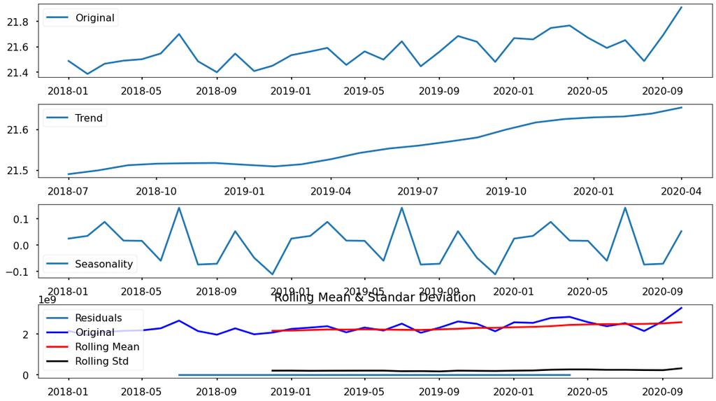

```
Results of Dickey-Fuller Test :
Test statistics               -2.455649
p-value                        0.126642
#Lags Used                     0.000000
Number of Observation Used    33.000000
Critical Value(1%)            -3.646135
Critical Value(5%)            -2.954127
Critical Value(10%)           -2.615968
dtype: float64
```

```python
from statsmodels.tsa.seasonal import seasonal_decompose
decomposition = seasonal_decompose(indexedDf_logScale)

trend = decomposition.trend
seasonal = decomposition.seasonal
residual = decomposition.resid

plt.subplot(411)
plt.plot(indexedDf_logScale,label ='Original')
plt.legend(loc='best')
plt.subplot(412)
plt.plot(trend,label='Trend')
plt.legend(loc='best')
plt.subplot(413)
plt.plot(seasonal,label ='Seasonality')
plt.legend(loc='best')
plt.subplot(414)
plt.plot(residual,label ='Residuals')
plt.legend(loc='best')
plt.tight_layout()

decomposedLogData = residual
decomposedLogData.dropna(inplace=True)
test_stationarity(decomposedLogData)
```

# ACF AND PACF PLOT

```python
#DETERMINE VALUE D
import numpy as np
ts_temp_log = np.log(indexedDf)
ts_temp_log
```

| period | EU |
| --- | --- |
| 2018-01-01 | 21.487162 |
| 2018-02-01 | 21.384755 |
| 2018-03-01 | 21.465085 |
| 2018-04-01 | 21.489584 |
| 2018-05-01 | 21.500821 |
| 2018-06-01 | 21.546507 |
| 2018-07-01 | 21.699829 |
| 2018-08-01 | 21.484823 |
| 2018-09-01 | 21.397984 |
| 2018-10-01 | 21.545171 |
| 2018-11-01 | 21.407497 |
| 2018-12-01 | 21.449165 |
| 2019-01-01 | 21.533137 |
| 2019-02-01 | 21.561749 |
| 2019-03-01 | 21.590477 |
| 2019-04-01 | 21.456054 |
| 2019-05-01 | 21.562666 |
| 2019-06-01 | 21.498105 |
| 2019-07-01 | 21.642390 |
| 2019-08-01 | 21.445160 |
| 2019-09-01 | 21.561189 |
| 2019-10-01 | 21.684197 |
| 2019-11-01 | 21.639031 |
| 2019-12-01 | 21.480365 |
| 2020-01-01 | 21.667689 |
| 2020-02-01 | 21.657631 |
| 2020-03-01 | 21.747646 |
| 2020-04-01 | 21.767461 |
| 2020-05-01 | 21.670680 |
| 2020-06-01 | 21.590273 |
| 2020-07-01 | 21.651669 |
| 2020-08-01 | 21.486668 |
| 2020-09-01 | 21.691064 |
| 2020-10-01 | 21.910906 |

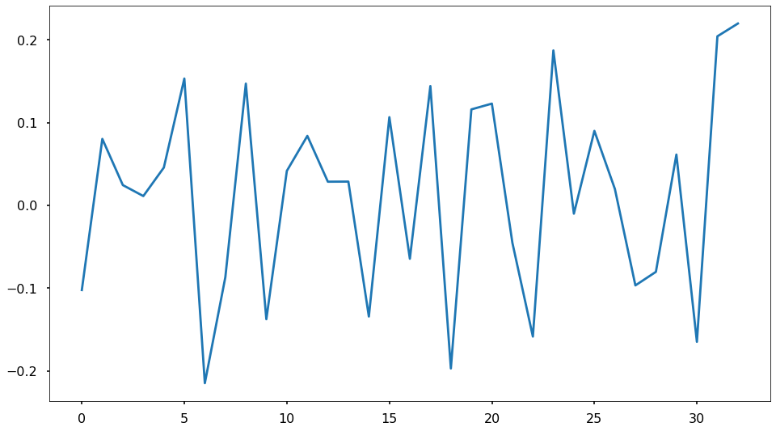

```python
ts_temp_log_diff = np.diff(ts_temp_log.EU)
plt.plot(ts_temp_log_diff)
```

# Determine P and Q value from ACF and PACF plot

We can learn some important properties of our time series data with the help of Auto Correlation(ACF) and Partial Auto Correlation (PACF) graphs.

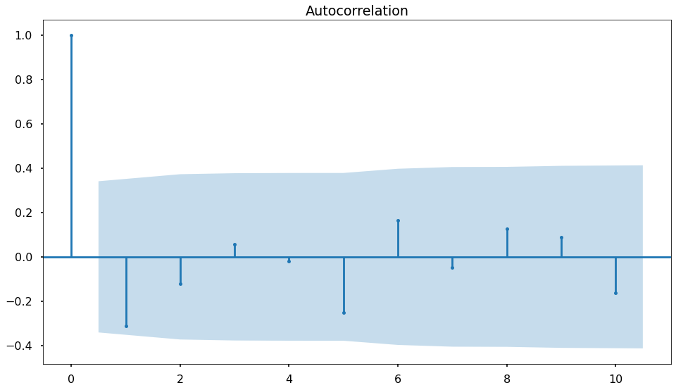

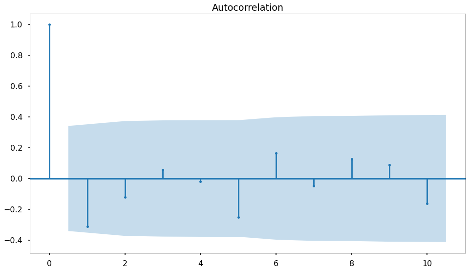

```python
#ACF --- nilai Q
from statsmodels.graphics.tsaplots import plot_acf
plot_acf(ts_temp_log_diff,lags=10)

#ACF is used to understand if there exists a correlation between
#a time series data point with another point as a function of their time difference
```

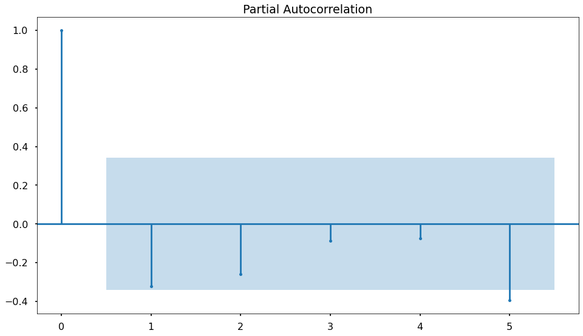

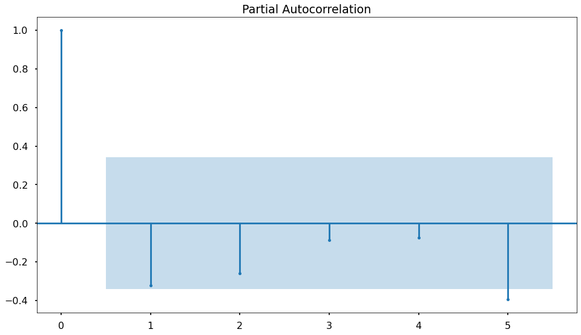

```python
#PACF --- nilai P
from statsmodels.graphics.tsaplots import plot_pacf
plt.figure(figsize=(10,2))
plot_pacf(ts_temp_log_diff,lags=5)
```

Remember our d value is 1 because our data was not stationary before differencing.

```python
from statsmodels.tsa.arima_model import ARIMA

#AR MODEL == from data we get p=1, q=0, d=1
model =ARIMA(indexedDf_logScale,order=(1,1,0))
results_AR = model.fit(disp=-1)
plt.plot(datasetLogDiffShifting)
plt.plot(results_AR.fittedvalues,color='red')
plt.title('RSS: %.4f'% sum((results_AR.fittedvalues-datasetLogDiffShifting["EU"])**2))
print('Plotting AR model')
```

[output not shown]

```
Plotting AR model
```

```python
#MA MODEL == from data we get p=3, q=3, d=1
model =ARIMA(indexedDf_logScale,order=(3,1,3))
results_MA = model.fit(disp=-1)
plt.plot(datasetLogDiffShifting)
plt.plot(results_MA.fittedvalues,color='red')
plt.title('RSS: %.4f'% sum((results_MA.fittedvalues-datasetLogDiffShifting["EU"])**2))
print('Plotting MA model')
```

[output not shown]

```
Plotting MA model
```

```python
model = ARIMA(indexedDf_logScale,order=(3,1,3))
results_ARIMA = model.fit(disp=-1)
plt.plot(datasetLogDiffShifting)
plt.plot(results_MA.fittedvalues,color='red')
plt.title('RSS: %.4f'% sum((results_ARIMA.fittedvalues-datasetLogDiffShifting["EU"])**2))
print('Plotting ARIMA model')
```

[output not shown]

```
Plotting ARIMA model
```

# AR, MA & ARMA Model

```python
# Import the ARMA model
from statsmodels.tsa.arima_model import ARMA

# Instantiate the model ARMA(1,1)
model = ARMA(indexedDf, order=(1,1))

# Fit the model
results = model.fit()
```

```python
print(results.summary())
```

```
                              ARMA Model Results
==============================================================================
Dep. Variable:                     EU   No. Observations:                   34
Model:                     ARMA(1, 1)   Log Likelihood                -706.558
Method:                       css-mle   S.D. of innovations      253611938.354
Date:                Sun, 31 Jan 2021   AIC                           1421.117
Time:                        15:16:50   BIC                           1427.222
Sample:                    01-01-2018   HQIC                          1423.199
                         - 10-01-2020
==============================================================================
                 coef    std err          z      P>|z|      [0.025      0.975]
------------------------------------------------------------------------------
const       2.347e+09   1.74e+08     13.454      0.000       2e+09    2.69e+09
ar.L1.EU       0.9489      0.080     11.929      0.000       0.793       1.105
ma.L1.EU      -0.7199      0.165     -4.362      0.000      -1.043      -0.396
                                    Roots
=============================================================================
                  Real          Imaginary           Modulus         Frequency
-----------------------------------------------------------------------------
AR.1            1.0538           +0.0000j            1.0538            0.0000
MA.1            1.3891           +0.0000j            1.3891            0.0000
-----------------------------------------------------------------------------
```

```python
predictions_ARIMA_diff = pd.Series(results_ARIMA.fittedvalues,copy=True)
print(predictions_ARIMA_diff.tail())
```

```
period
2020-06-01   -0.017482
2020-07-01    0.112285
2020-08-01    0.006193
2020-09-01    0.139523
2020-10-01    0.052733
Freq: MS, dtype: float64
```

```python
#CONVERT TO CUMULATIVE SUM
predictions_ARIMA_diff_cumsum = predictions_ARIMA_diff.cumsum()
print(predictions_ARIMA_diff_cumsum.head)
```

```
<bound method NDFrame.head of period
2018-02-01    0.007908
2018-03-01    0.060673
2018-04-01    0.078202
2018-05-01    0.046329
2018-06-01    0.045066
2018-07-01    0.025660
2018-08-01   -0.123977
2018-09-01   -0.080230
2018-10-01    0.069402
2018-11-01    0.045546
2018-12-01    0.133479
2019-01-01    0.257559
2019-02-01    0.238752
2019-03-01    0.216478
2019-04-01    0.241361
2019-05-01    0.302694
2019-06-01    0.311716
2019-07-01    0.404774
2019-08-01    0.344398
2019-09-01    0.450362
2019-10-01    0.520417
2019-11-01    0.431494
2019-12-01    0.402480
2020-01-01    0.556071
2020-02-01    0.508034
2020-03-01    0.471037
2020-04-01    0.435355
2020-05-01    0.328897
2020-06-01    0.311415
2020-07-01    0.423700
2020-08-01    0.429893
2020-09-01    0.569416
2020-10-01    0.622149
Freq: MS, dtype: float64>
```

```python
predictions_ARIMA_log = pd.Series(indexedDf_logScale['EU'],index=indexedDf_logScale.index)
predictions_ARIMA_log = predictions_ARIMA_log.add(predictions_ARIMA_diff_cumsum,fill_value=0)
predictions_ARIMA_log.head()
```

```
period
2018-01-01    21.487162
2018-02-01    21.392663
2018-03-01    21.525759
2018-04-01    21.567786
2018-05-01    21.547150
Freq: MS, dtype: float64
```

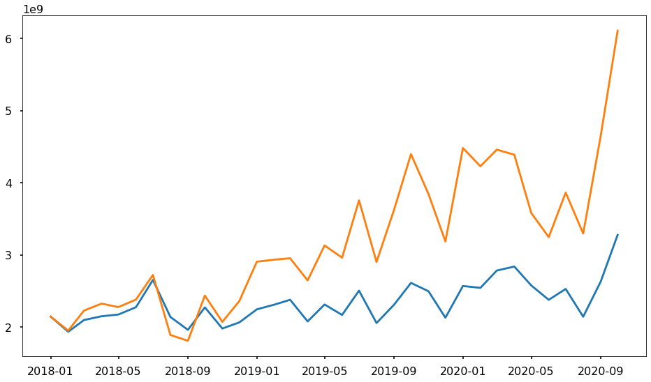

```python
predictions_ARIMA = np.exp(predictions_ARIMA_log)
plt.plot(indexedDf)
plt.plot(predictions_ARIMA)
```

```python
indexedDf_logScale
```

| period | EU |
| --- | --- |
| 2018-01-01 | 21.487162 |
| 2018-02-01 | 21.384755 |
| 2018-03-01 | 21.465085 |
| 2018-04-01 | 21.489584 |
| 2018-05-01 | 21.500821 |
| 2018-06-01 | 21.546507 |
| 2018-07-01 | 21.699829 |
| 2018-08-01 | 21.484823 |
| 2018-09-01 | 21.397984 |
| 2018-10-01 | 21.545171 |
| 2018-11-01 | 21.407497 |
| 2018-12-01 | 21.449165 |
| 2019-01-01 | 21.533137 |
| 2019-02-01 | 21.561749 |
| 2019-03-01 | 21.590477 |
| 2019-04-01 | 21.456054 |
| 2019-05-01 | 21.562666 |
| 2019-06-01 | 21.498105 |
| 2019-07-01 | 21.642390 |
| 2019-08-01 | 21.445160 |
| 2019-09-01 | 21.561189 |
| 2019-10-01 | 21.684197 |
| 2019-11-01 | 21.639031 |
| 2019-12-01 | 21.480365 |
| 2020-01-01 | 21.667689 |
| 2020-02-01 | 21.657631 |
| 2020-03-01 | 21.747646 |
| 2020-04-01 | 21.767461 |
| 2020-05-01 | 21.670680 |
| 2020-06-01 | 21.590273 |
| 2020-07-01 | 21.651669 |
| 2020-08-01 | 21.486668 |
| 2020-09-01 | 21.691064 |
| 2020-10-01 | 21.910906 |

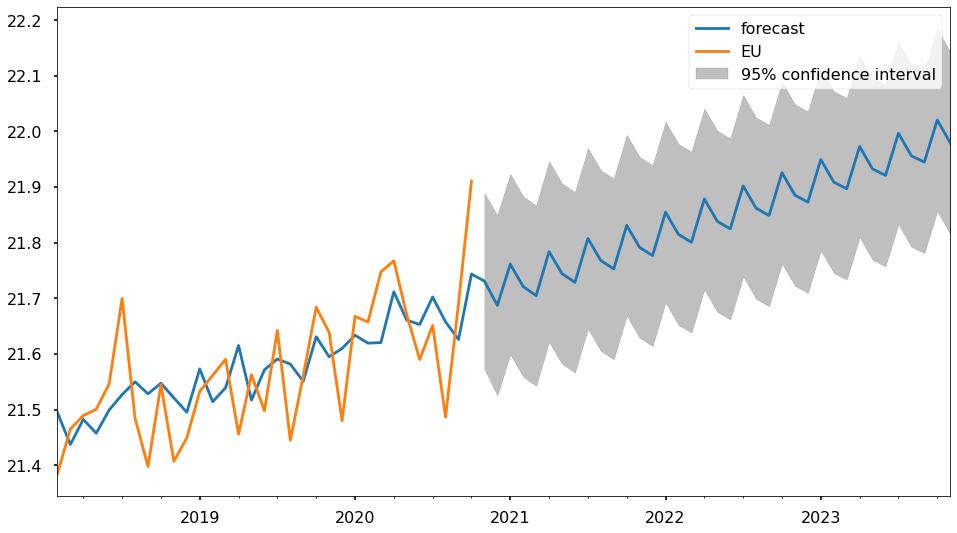

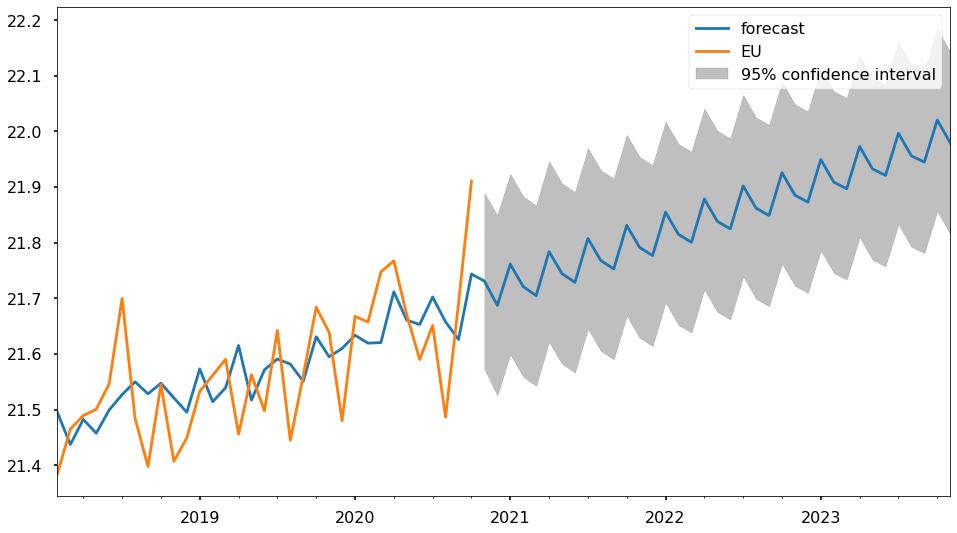

```python
#result ARIMA ( I want to predict 3 year , 34 + 36 = 70 )
results_ARIMA.plot_predict(1,70)
```

```python
x=results_ARIMA.forecast(steps=70)
```

```python
x[0]
```

```
array([21.73124441, 21.68747063, 21.761652  , 21.72124634, 21.70499485,
       21.78404351, 21.74450913, 21.7289627 , 21.80768222, 21.76801602,
       21.75297676, 21.83132854, 21.7915268 , 21.77699046, 21.85497349,
       21.81503973, 21.80100348, 21.87861701, 21.83855478, 21.82501578,
       21.90225911, 21.86207196, 21.84902737, 21.92589982, 21.88559125,
       21.87303824, 21.94953915, 21.90911264, 21.89704837, 21.97317711,
       21.93263614, 21.92105775, 21.99681372, 21.95616174, 21.94506639,
       22.020449  , 21.97968942, 21.96907426, 22.04408295, 22.00321918,
       21.99308136, 22.0677156 , 22.02675103, 22.01708769, 22.09134696,
       22.05028494, 22.04109322, 22.11497705, 22.07382091, 22.06509796,
       22.13860587, 22.09735894, 22.08910189, 22.16223345, 22.12089903,
       22.11310502, 22.1858598 , 22.14444115, 22.13710732, 22.20948494,
       22.16798531, 22.16110879, 22.23310887, 22.1915315 , 22.18510942,
       22.25673162, 22.21507972, 22.20910921, 22.2803532 , 22.23862995])
```

```python
x[1]
```

```
array([0.08058348, 0.08266329, 0.08266894, 0.08266894, 0.08271604,
       0.08274176, 0.08274376, 0.08278655, 0.08281288, 0.08281477,
       0.08285699, 0.08288337, 0.08288514, 0.08292682, 0.08295324,
       0.08295489, 0.08299603, 0.0830225 , 0.08302403, 0.08306463,
       0.08309114, 0.08309257, 0.08313264, 0.08315918, 0.0831605 ,
       0.08320005, 0.08322662, 0.08322784, 0.08326686, 0.08329347,
       0.08329459, 0.0833331 , 0.08335973, 0.08336076, 0.08339875,
       0.08342541, 0.08342636, 0.08346383, 0.08349052, 0.08349138,
       0.08352835, 0.08355505, 0.08355583, 0.0835923 , 0.08361902,
       0.08361973, 0.0836557 , 0.08368243, 0.08368307, 0.08371854,
       0.08374528, 0.08374585, 0.08378084, 0.08380759, 0.0838081 ,
       0.08384259, 0.08386935, 0.0838698 , 0.08390382, 0.08393057,
       0.08393097, 0.08396451, 0.08399126, 0.08399161, 0.08402467,
       0.08405142, 0.08405172, 0.08408432, 0.08411106, 0.08411132])
```